# event study bnps and apartments, moves and disadvantage

Devraj Kori

3/13/2020

Event study possible specification
$$Y_{i,ht} = \sum_{\tau=-q}^m(\beta_{\tau}D^{\tau}_{i,h,t}) + \theta_{h} + \psi_t + \epsilon_{i,h,t}$$

- $Y_{i,h,t}$ is equal to 1 if individual i in neighborhood h moves in time t.
- $\tau$ is an event-time indicator which is equal to the difference between year t and the year that the apartment was constructed.
- $D^{\tau}_{i,h,t}$ is a set of event-time dummies equal to 1 if individual i in neighborhood h is within the treatment range around the location of the new apartment.
- $\theta_h$ represents neighborhood fixed-effects
- $\psi_t$ represents year fixed effects
- $\epsilon_{i,h,t}$ is the error term, which should be uncorrelated with the other terms.
- If there is a causal effect of the construction of a new apartment on displacement of nearby voucher residents, then the $\beta_{\tau}$ values will be close to zero for values of $\tau$ less than zero, and will be positive for values of $\tau$ greater than 0.
- Untreated observations for a given event serve as the control, most rows will be untreated
- The treatment range will be a ring around each new apartment location
- Rows are repeated for each event where an individual is treated. If individual i’s location in year t is in the treatment range for two different events, the rows corresponding to i and t will be repeated for each event, with different taus assigned depending on when each apartment opened.
- Some rows will be eliminated if we can identify that individuals have been forcibly displaced prior to the construction of an apartment (i.e, if forced out by a landlord to make room for new construction)

```r
#define ring around the apartment that we'll consider the "treatment area"
 #creating a ring so that move-outs from whatever building existed on the same plot of land the apartment is on arent' included

#distances in meters
inner_distance<-100%>%units::set_units(m)
outer_distance<-1000%>%units::set_units(m)

#define binning, the maximum number of years before/after an opening to include
years_prior<-(6)
years_after<-(6)

#set Tau to normalize around (Tau that is forced to be 0)
zero_tau=(-1)

#selct neighborhoods to include
included_neighborhoods<-c("East Liberty", "Homewood","Homewood West", "Homewood South","Homewood North",
                          "Larimer","Point Breeze","Point Breeze North", "East Hills", "Swisshelm Park",
                          "Shadyside", "Squirrel Hill North", "Squirrel Hill South", "Garfield", "Bloomfield",
                          "Highland Park", "Morningside",
                          "Greenfield", "Hazelwood","Glen Hazel", "Lincoln-Lemington-Belmar",
                          "Lower Lawrenceville", "Upper Lawrenceville", "Central Lawrenceville",
                          "Morningside", "Stanton Heights")

races_included<-c("Black/African American",
                  "Multi-Racial",
                  "Asian",
                  "Native Hawaiian/Other Pacific Islander",
                  "American Indian/Alaska Native",
                  "White")
#races_included<-"Black/African American"
#included_neighborhoods<-c("East Liberty","Homewood")
```

```r
# #read in new apartment complex data
# new_apartments<-read_csv("New Pgh Apartments - Large market-rate apts since 1999 - cleaned.csv")%>%
#   #remove NAS
#   filter(!is.na(lon))%>%
#   #make it sf object
#   st_as_sf(coords=c("lon","lat"),crs = "+init=epsg:4326")
#read in the bnps
# load("bnps re-geocoded.Rdata")
# bnps<-bnps_recoded
load("combined apartments commercial bnps.Rdata")

#read in zoning data
zoning<-read_sf("zoning/zoning.geojson")%>%
  select(full_zoning_type)

#read in east end moves for disadvantage
load("east end moves.Rdata")

#move the directory up a level (outside "quantitative analysis into main folder)
setwd("..")

load("cleaned and geocoded data 01-April.Rdata")

#load pittsburgh neighborhood shapefile
neighborhoods<-read_sf("data preparation/geocode addresses/Neighborhoods_/Neighborhoods_.shx")%>%
  select(hood,geometry)

#limit apartments/bnps combined to just selected neighborhoods
combined<-apartments_commercial_bnps%>%
  st_join(neighborhoods,st_within)%>%
  filter(hood%in%included_neighborhoods)%>%
  select(-hood)%>%
  #remove affordable-only
  filter(Type!="Affordable Only")
```

```
## although coordinates are longitude/latitude, st_within assumes that they are planar
```

```r
#change the type for Rippey street to Mixed income
combined[combined$Development.Projects=="Rippey Apartment Complex",]$Type<-"Mixed-income"
combined[combined$Development.Projects=="East Mall Apartments",]$Type<-"Mixed-income"
#join dat_cleaned5 with
geocoded_data<-cleaned_and_geocoded%>%
  #remove NA move-outs, since this version is only looking at displacements
  filter(!is.na(MOVEOUTDATE))%>%
  select(HA, CLIENT_ID, GENDER, RACE, MOVEINDATE, MOVEOUTDATE, PRIMARYSTREET, ZIP,hood,geometry)%>%
  filter(hood%in%included_neighborhoods)%>%
  #join with zoning data
  st_join(zoning,join=st_within)%>%
  filter(RACE%in%races_included)
```

```
## although coordinates are longitude/latitude, st_within assumes that they are planar
```

```r
#join dat_cleaned5 with
disadvantages<-moves%>%
  st_as_sf()%>%
  filter(start_hood%in%included_neighborhoods)%>%
  #join with zoning data
  st_join(zoning,join=st_within)%>%
  filter(race%in%races_included)%>%
  # add a year column
  mutate(t=as.numeric(format(moveout_date,"%Y")))
```

```
## although coordinates are longitude/latitude, st_within assumes that they are planar
```

Create a year dataset, where each row corresponds to all of the instances of people living in an apartment in a given year

```r
year_range<-2003:2019
for(year in year_range){
  year_frame<-geocoded_data%>%
    #create movein and moveout year variables to filter by
    mutate(movein_year=as.numeric(format(MOVEINDATE,"%Y")),
           moveout_year=as.numeric(format(MOVEOUTDATE,"%Y")))%>%
    #filter to only include rows where the stay includes that year
    filter(movein_year<=year & moveout_year<=year)%>%
    #create a flag indicating if they moved out in that year
    mutate(moved_out=(moveout_year==year))%>%
    #add a year column
    mutate(t=year)%>%
    #if an individual moves during a year, we only want the first instance of them moving, so only grab row corresponding to the earlier move-in date
    group_by(CLIENT_ID,t)%>%
    slice(which.min(MOVEINDATE))%>%
    ungroup()%>%
    #remove move-in/move-out fields since they're not relevant in this structure
    select(-c(MOVEINDATE,MOVEOUTDATE,movein_year,moveout_year))

  #bind results
  if(year==year_range[1]){
    panel_frame<-year_frame
  }else{
    panel_frame<-rbind(year_frame,panel_frame)
  }
}
```

```r
#calculate distances between new apartments and geocoded data
distances_moves<-st_distance(apartments_commercial_bnps$geometry,
                       panel_frame$geometry)

#limit to just addresses that fall within specified range of each new apartment
in_range_moves<-which(distances_moves>=inner_distance & distances_moves<=outer_distance,arr.ind=TRUE)%>%as.data.frame

#remove distances to preserve memory
#rm(distances)
```

```r
#calculate distances between new apartments and geocoded data
distances_disadvantages<-st_distance(apartments_commercial_bnps$geometry,
                       disadvantages$geometry)

#limit to just addresses that fall within specified range of each new apartment
in_range_disadvantages<-which(distances_disadvantages>=inner_distance & distances_disadvantages<=outer_distance,arr.ind=TRUE)%>%as.data.frame

#remove distances to preserve memory
#rm(distances)
```

```r
#i<-1
#create a vector of rows in new_apartments
bnp_indices<-1:nrow(combined)

# this function returns a dataframe for a given event, with an event-time Tau value assigned to events in the treatment range. Untreated events are returned with a Tau value of 999
# rows outside of the treatment range are assigned Tau=0 for all rows
event_frame_function<-function(i,df,in_range){
  #print(i)
  #define apartment date
  event_year<-combined[i,]$`Date-Completed`%>%as.numeric()
  event_name<-combined[i,]$`Development.Projects`
  event_type<-combined[i,]$Type
  #define range of years based on chosen years before/after
  year_range<-(event_year-years_prior):(event_year+years_after)

  #retrieve address indices in range
  voucher_indices_in_range<-in_range[in_range$row==i,]$col

  #define rows in treatment, create a tau variable
  treated_rows<-df%>%
    #limit just to rows in distance range of given event
    slice(voucher_indices_in_range)%>%
    #define tau as difference between t and apartment_year
    mutate(Tau=t-event_year)%>%
    # limit only to years in year_range
    filter(t%in%year_range)%>%
    #add event name and event type
    mutate(event=event_name,
           type=event_type)


  #untreated rows serve as control, so define those too
  untreated_rows<-df%>%
    #limit just to rows outside distance range of given event
    slice(-voucher_indices_in_range)%>%
    #define tau as 999 (so it can be dropped later)
    mutate(Tau=999)%>%
    # limit only to years in year_range
    filter(t%in%year_range)%>%
    #create a blank event_name field for untreated rows
    mutate(event="none",
           type="none")

  #return the binding of the two
  rbind(treated_rows,untreated_rows)
}

#create a function that takes a dataframe as its argument and creates dummies for each tau value
tau_dummies<-function(df){
  #make tau a factor
  df$Tau<-factor(df$Tau)
  #iterate through the levels of Tau, create a dummy in a new frame named "Tau_-x" and bind to df
  #x<-levels(df$Tau)[2]

  for(x in levels(df$Tau)){
    dummy_frame<-data.frame(col=(df$Tau==x))
    #set the name to be "Tau_-x"
    names(dummy_frame)<-paste0("Tau_",x)
    df<-bind_cols(df,dummy_frame)
  }
  df
}

#call event frame function over bnp indices
# apply the event frame fucntion to each of the events (by using the row indices of the BNP frame)
  # do this separately for
# for_event_study_list<-lapply(bnp_indices,event_frame_function())
# test<-for_event_study_list[[1]]
# using do.call on rbind binds each event's rows together
for_event_study_moves<-do.call(rbind,
                               lapply(bnp_indices,function(x)event_frame_function(i=x,
                                                                                  df=panel_frame,
                                                                                  in_range=in_range_moves)))%>%
  #add tau dummies
  tau_dummies()%>%
  #remove the dummy for tau_999, corresponding to untreated events
  select(-Tau_999)%>%
  unique()
for_event_study_disadvantage<-do.call(rbind,
                               lapply(bnp_indices,function(x) event_frame_function(i=x,
                                                                                   df=disadvantages,
                                                                                   in_range=in_range_disadvantages)))%>%
  #add tau dummies
  tau_dummies()%>%
  #remove the dummy for tau_999, corresponding to untreated events
  select(-Tau_999)%>%
  unique()%>%
  #add field for disadvantage change, which will be the outcome
  mutate(disadvantage_change=end_disadvantage-start_disadvantage)
```

```r
#create the formula for the event study
taus_list<-c()
for(tau in levels(for_event_study_moves$Tau)){
  taus_list<-c(taus_list,paste0("`Tau_",tau,"`"))
}
#remove taus_list
taus_list<-taus_list[taus_list!="`Tau_999`"]
#remove tau for normalized year
norm_year_tau<-paste0("`Tau_",zero_tau,"`")
taus_list<-taus_list[taus_list!=norm_year_tau]

taus_string<-paste0(taus_list,collapse=" + ")
formula<-as.formula(paste0("moved_out~",taus_string))

test_run<-lm_robust(formula,data=for_event_study_moves,fixed_effects=t+hood+full_zoning_type,clusters=hood,
                    se_type="stata")
summary(test_run)
```

```
##
## Call:
## lm_robust(formula = formula, data = for_event_study_moves, clusters = hood,
##     fixed_effects = t + hood + full_zoning_type, se_type = "stata")
##
## Standard error type:  stata
##
## Coefficients:
##                Estimate Std. Error  t value Pr(>|t|)   CI Lower   CI Upper
## `Tau_-6`TRUE  1.453e-02   0.004406  3.29685 0.003154  5.411e-03  0.0236402
## `Tau_-5`TRUE  4.271e-03   0.005831  0.73236 0.471344 -7.793e-03  0.0163341
## `Tau_-4`TRUE  4.879e-03   0.003388  1.44017 0.163292 -2.129e-03  0.0118870
## `Tau_-3`TRUE -7.035e-05   0.003790 -0.01856 0.985349 -7.910e-03  0.0077696
## `Tau_-2`TRUE  7.172e-03   0.003441  2.08440 0.048420  5.416e-05  0.0142902
## Tau_0TRUE     2.717e-03   0.005600  0.48519 0.632129 -8.867e-03  0.0143004
## Tau_1TRUE    -7.833e-03   0.003458 -2.26542 0.033214 -1.499e-02 -0.0006803
## Tau_2TRUE    -4.321e-03   0.002400 -1.80068 0.084883 -9.285e-03  0.0006431
## Tau_3TRUE    -5.460e-03   0.002790 -1.95722 0.062566 -1.123e-02  0.0003109
## Tau_4TRUE    -1.089e-02   0.003491 -3.11959 0.004818 -1.811e-02 -0.0036693
## Tau_5TRUE     4.018e-03   0.005401  0.74397 0.464427 -7.155e-03  0.0151913
## Tau_6TRUE    -4.859e-04   0.006655 -0.07301 0.942432 -1.425e-02  0.0132817
##              DF
## `Tau_-6`TRUE 23
## `Tau_-5`TRUE 23
## `Tau_-4`TRUE 23
## `Tau_-3`TRUE 23
## `Tau_-2`TRUE 23
## Tau_0TRUE    23
## Tau_1TRUE    23
## Tau_2TRUE    23
## Tau_3TRUE    23
## Tau_4TRUE    23
## Tau_5TRUE    23
## Tau_6TRUE    23
##
## Multiple R-squared:  0.1857 ,    Adjusted R-squared:  0.1851
## Multiple R-squared (proj. model):  0.000255 ,    Adjusted R-squared (proj. model):  -0.0004443
## F-statistic (proj. model): 20.58 on 12 and 23 DF,  p-value: 1.739e-09
```

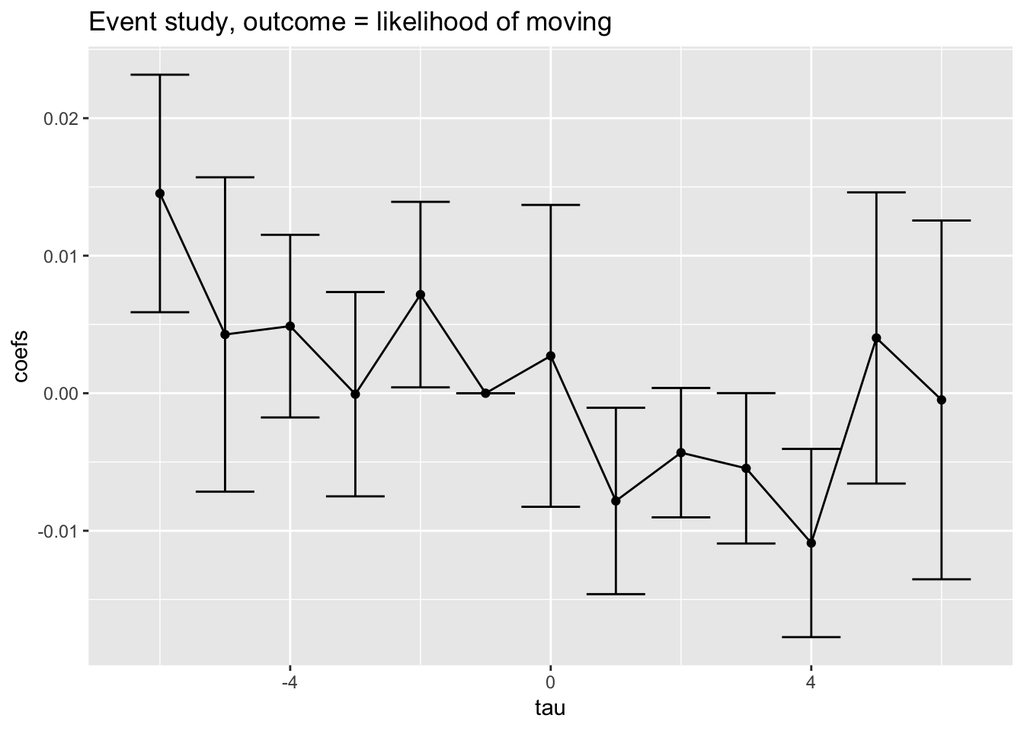

```r
data.frame(coefs=test_run$coefficients,
           tau_string=names(test_run$coefficients),
           #specify range as 1.96*sd
           error=test_run$std.error*1.96)%>%
  #add in the zero tau
  rbind(data.frame(coefs=0,
                   tau_string=norm_year_tau,
                   error=0))%>%
  #make tau numeric
  mutate(tau_string=gsub('`','',tau_string),
         tau=as.numeric(gsub('Tau_|TRUE','',tau_string,)))%>%
  ggplot(aes(x=tau,y=coefs))+
  geom_point(aes(x=tau,y=coefs))+
  geom_line()+
  geom_errorbar(aes(ymin=coefs-error,ymax=coefs+error))+
  labs(title="Event study, outcome = likelihood of moving")
```

```r
#create the formula for the event study
taus_list<-c()
for(tau in levels(for_event_study_disadvantage$Tau)){
  taus_list<-c(taus_list,paste0("`Tau_",tau,"`"))
}
#remove taus_list
taus_list<-taus_list[taus_list!="`Tau_999`"]

taus_string<-paste0(taus_list,collapse=" + ")
formula<-as.formula(paste0("disadvantage_change~",taus_string))

test_run<-lm_robust(formula,data=for_event_study_disadvantage,fixed_effects=t+start_hood+full_zoning_type,clusters=start_hood,se_type="stata")
summary(test_run)
```

```
##
## Call:
## lm_robust(formula = formula, data = for_event_study_disadvantage,
##     clusters = start_hood, fixed_effects = t + start_hood + full_zoning_type,
##     se_type = "stata")
##
## Standard error type:  stata
##
## Coefficients:
##                Estimate Std. Error  t value Pr(>|t|)   CI Lower CI Upper
## `Tau_-6`TRUE  0.0016276   0.005496  0.29617 0.769755 -0.0097408 0.012996
## `Tau_-5`TRUE  0.0198593   0.008958  2.21703 0.036784  0.0013290 0.038390
## `Tau_-4`TRUE -0.0055896   0.006585 -0.84883 0.404725 -0.0192118 0.008033
## `Tau_-3`TRUE  0.0077165   0.002729  2.82769 0.009542  0.0020713 0.013362
## `Tau_-2`TRUE -0.0113446   0.008683 -1.30652 0.204291 -0.0293071 0.006618
## `Tau_-1`TRUE -0.0102083   0.005985 -1.70565 0.101543 -0.0225891 0.002173
## Tau_0TRUE    -0.0012861   0.006365 -0.20205 0.841654 -0.0144541 0.011882
## Tau_1TRUE     0.0004041   0.007124  0.05672 0.955260 -0.0143338 0.015142
## Tau_2TRUE     0.0132704   0.006723  1.97375 0.060541 -0.0006381 0.027179
## Tau_3TRUE     0.0111361   0.009574  1.16317 0.256685 -0.0086690 0.030941
## Tau_4TRUE     0.0095769   0.013875  0.69022 0.496960 -0.0191259 0.038280
## Tau_5TRUE    -0.0034192   0.003693 -0.92592 0.364101 -0.0110581 0.004220
## Tau_6TRUE     0.0015636   0.008062  0.19394 0.847923 -0.0151147 0.018242
##              DF
## `Tau_-6`TRUE 23
## `Tau_-5`TRUE 23
## `Tau_-4`TRUE 23
## `Tau_-3`TRUE 23
## `Tau_-2`TRUE 23
## `Tau_-1`TRUE 23
## Tau_0TRUE    23
## Tau_1TRUE    23
## Tau_2TRUE    23
## Tau_3TRUE    23
## Tau_4TRUE    23
## Tau_5TRUE    23
## Tau_6TRUE    23
##
## Multiple R-squared:  0.3968 ,    Adjusted R-squared:  0.3904
## Multiple R-squared (proj. model):  0.001795 ,    Adjusted R-squared (proj. model):  -0.008665
## F-statistic (proj. model): 6.846 on 13 and 23 DF,  p-value: 3.561e-05
```

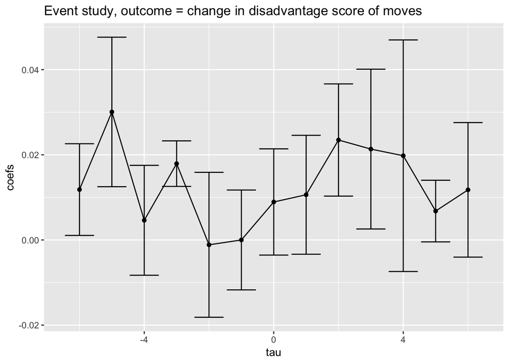

```r
for_normalization<-test_run$coefficients[paste0("`Tau_",zero_tau,"`TRUE")]
data.frame(coefs=test_run$coefficients-for_normalization,
           tau_string=names(test_run$coefficients),
           #specify range as 1.96*sd
           error=test_run$std.error*1.96)%>%
  #make tau numeric
  mutate(tau_string=gsub('`','',tau_string),
         tau=as.numeric(gsub('Tau_|TRUE','',tau_string,)))%>%
  ggplot(aes(x=tau,y=coefs))+
  geom_point(aes(x=tau,y=coefs))+
  geom_line()+
  geom_errorbar(aes(ymin=coefs-error,ymax=coefs+error))+
  labs(title="Event study, outcome = change in disadvantage score of moves")
```

```r
# tau_minus_4<-for_event_study%>%
#   filter(`Tau_-4`==1)
# test<-tau_minus_4%>%
#   group_by(event)%>%
#   summarise(move_pct=mean(moved_out),
#             rows=n())
#
# target_minus_3<-tau_minus_3%>%
#   filter(event=="Target")
#
# leaflet()%>%
#   addProviderTiles(providers$CartoDB.Positron)%>%
#   addCircleMarkers(data=target_minus_3,
#                    radius=5,
#                    stroke=FALSE)%>%
#   addCircleMarkers(data=apartments_commercial_bnps%>%
#                      filter(`Development.Projects`=="Target"),
#                    radius=5,
#                    stroke=FALSE,
#                    color="red")
```